# MeLSI Tutorial: Basic Usage and Examples

Nathan Bresette

2025-12-23

# MeLSI Tutorial

This tutorial provides a comprehensive introduction to MeLSI (Metric Learning for Statistical Inference) for microbiome data analysis.

## Introduction

MeLSI is a novel machine learning method that learns optimal distance metrics to improve statistical power in detecting group differences in microbiome data. Unlike traditional distance metrics (Bray-Curtis, Euclidean, Jaccard), MeLSI adapts to the specific characteristics of your dataset.

## Installation and Setup

```r
# Install devtools if not already installed
if (!require("devtools", quietly = TRUE))
    install.packages("devtools")

# Install required packages
if (!require("BiocManager", quietly = TRUE))
    install.packages("BiocManager")

BiocManager::install(c("phyloseq", "microbiome"))
install.packages(c("vegan", "ggplot2"))

# Install MeLSI from GitHub
devtools::install_github("NathanBresette/MeLSI")
```

## Basic Usage

### Step 1: Prepare Your Data

```r
# Load required packages
library(MeLSI)
library(vegan)
library(ggplot2)

# Generate synthetic microbiome data for demonstration
set.seed(42)
test_data <- generate_test_data(n_samples = 60, n_taxa = 100, n_signal_taxa = 10)
X <- test_data$counts
y <- test_data$metadata$Group

# Display data dimensions
cat("Data dimensions:", nrow(X), "samples x", ncol(X), "taxa\n")
```

```
## Data dimensions: 60 samples x 100 taxa
```

```r
cat("Groups:", paste(unique(y), collapse = ", "), "\n")
```

```
## Groups: A, B
```

### Step 2: Data Preprocessing

```r
# CLR transformation (recommended for microbiome data)
# Use the built-in helper function for easy CLR transformation
X_clr <- clr_transform(X)

# Display preprocessing results
cat("CLR transformation completed\n")
```

```
## CLR transformation completed
```

```r
cat("Data range:", round(range(X_clr), 3), "\n")
```

```
## Data range: -4.144 2.206
```

### Step 3: Run MeLSI Analysis

```r
# Run MeLSI with default parameters
# Note: For real analyses, use n_perms = 200+ for reliable p-values
# Using 99 here for faster vignette execution
cat("Running MeLSI analysis...\n")
```

```
## Running MeLSI analysis...
```

```r
melsi_results <- melsi(
    X_clr, y,
    n_perms = 99,    # Number of permutations (use 200+ for real analysis)
    B = 30,          # Number of weak learners
    m_frac = 0.8,    # Fraction of features per learner
    show_progress = TRUE
)
```

[output not shown]

[output cut: 47 more lines]

[output not shown]

```
## Analysis completed!
## F-statistic: 1.375
## P-value: 0.2
##
## Feature importance: Access results$feature_weights to see which taxa
## contributed most to the learned distance metric.
## Directionality: Access results$directionality to see which group has higher abundance.
##
## Top 5 most important features:
##   1. Taxa60 (weight: 4.5577) [Higher in A]
##   2. Taxa7 (weight: 3.9955) [Higher in B]
##   3. Taxa1 (weight: 3.8401) [Higher in B]
##   4. Taxa59 (weight: 3.8153) [Higher in A]
##   5. Taxa73 (weight: 3.7811) [Higher in A]
```

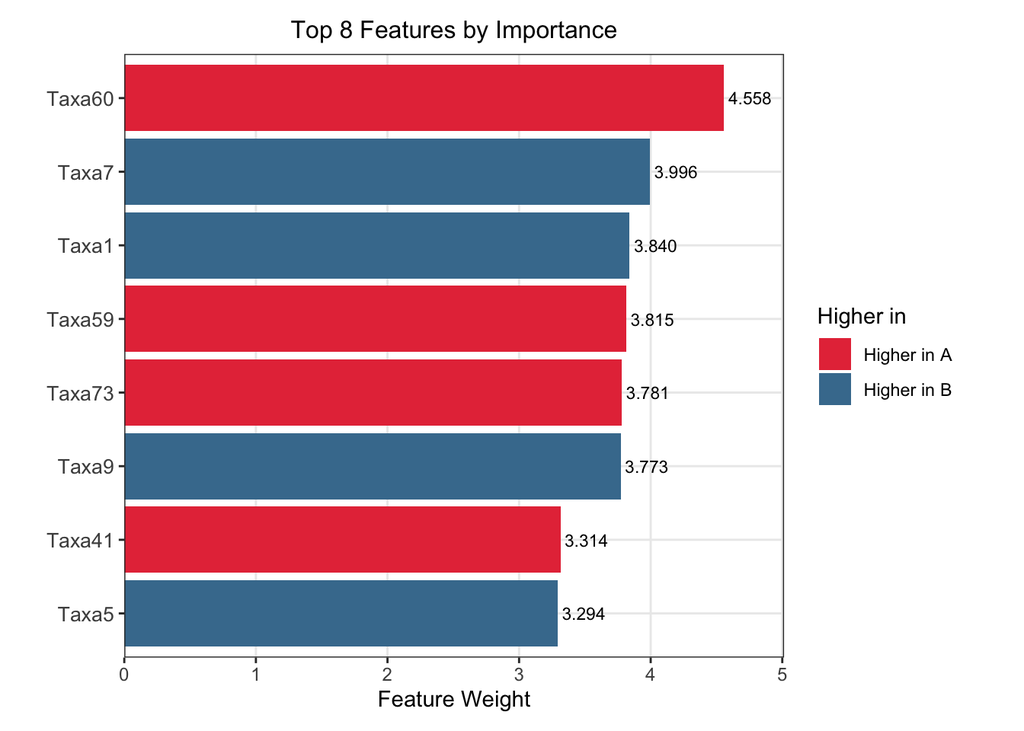

```r
# Display results
cat("\nMeLSI Results:\n")
```

```
##
## MeLSI Results:
```

```r
cat(sprintf("F-statistic: %.4f\n", melsi_results$F_observed))
```

```
## F-statistic: 1.3750
```

```r
cat(sprintf("P-value: %.4f\n", melsi_results$p_value))
```

```
## P-value: 0.2000
```

```r
cat(sprintf("Significant: %s\n", ifelse(melsi_results$p_value < 0.05, "Yes", "No")))
```

```
## Significant: No
```

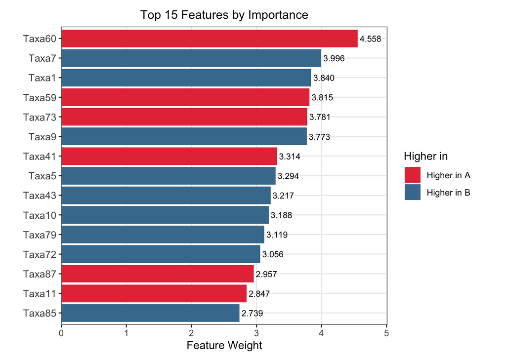

```r
# VIP plot is automatically generated, but you can also create it manually:
plot_vip(melsi_results, top_n = 15)
```

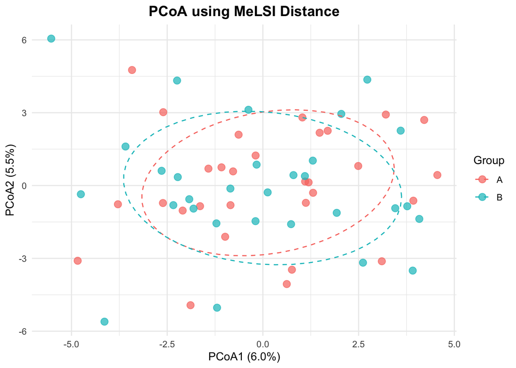

```r
# PCoA plot using the learned MeLSI distance
plot_pcoa(melsi_results, X_clr, y)
```

## Comparison with Standard Methods

```r
# Compare with Euclidean distance
dist_euclidean <- dist(X_clr)
adonis_euclidean <- adonis2(dist_euclidean ~ y, permutations = 99)

# Compare with Bray-Curtis distance
dist_bray <- vegdist(X, method = "bray")
adonis_bray <- adonis2(dist_bray ~ y, permutations = 99)

# Display comparison results
cat("\nMethod Comparison:\n")
```

```
##
## Method Comparison:
```

```r
cat(sprintf("MeLSI:        F = %.4f, p = %.4f\n",
           melsi_results$F_observed, melsi_results$p_value))
```

```
## MeLSI:        F = 1.3750, p = 0.2000
```

```r
cat(sprintf("Euclidean:    F = %.4f, p = %.4f\n",
           adonis_euclidean$F[1], adonis_euclidean$`Pr(>F)`[1]))
```

```
## Euclidean:    F = 1.1818, p = 0.1300
```

```r
cat(sprintf("Bray-Curtis: F = %.4f, p = %.4f\n",
           adonis_bray$F[1], adonis_bray$`Pr(>F)`[1]))
```

```
## Bray-Curtis: F = 9.6419, p = 0.0100
```

```r
# Calculate improvement
improvement <- (melsi_results$F_observed - adonis_euclidean$F[1]) / adonis_euclidean$F[1] * 100
cat(sprintf("\nMeLSI improvement over Euclidean: %.1f%%\n", improvement))
```

```
##
## MeLSI improvement over Euclidean: 16.4%
```

## Visualizing Results

### Variable Importance Plot (VIP)

MeLSI automatically generates a VIP plot showing which features drive group differences. You can customize it using the `plot_vip()` function:

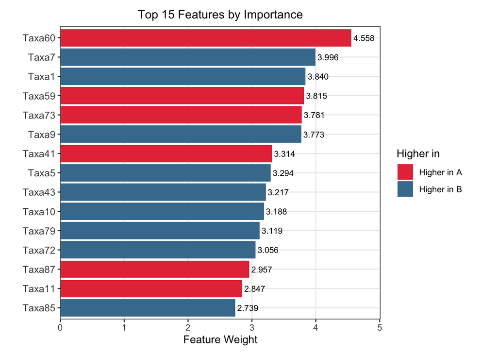

```r
# Plot VIP with directionality (default)
plot_vip(melsi_results, top_n = 15, title = "Top 15 Features by Importance")
```

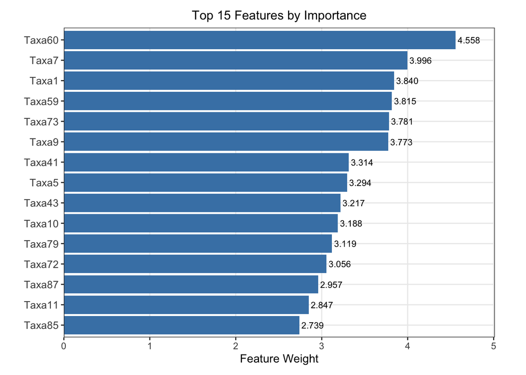

```r
# Plot VIP without directionality coloring
plot_vip(melsi_results, top_n = 15, directionality = FALSE)
```

```r
# Extract and examine feature weights programmatically
feature_weights <- melsi_results$feature_weights
top_features <- head(sort(feature_weights, decreasing = TRUE), 10)

cat("\nTop 10 Most Weighted Features:\n")
```

```
##
## Top 10 Most Weighted Features:
```

```r
for (i in 1:length(top_features)) {
    cat(sprintf("%2d. %s (weight: %.4f)\n",
               i, names(top_features)[i], top_features[i]))
}
```

```
##  1. Taxa60 (weight: 4.5577)
##  2. Taxa7 (weight: 3.9955)
##  3. Taxa1 (weight: 3.8401)
##  4. Taxa59 (weight: 3.8153)
##  5. Taxa73 (weight: 3.7811)
##  6. Taxa9 (weight: 3.7727)
##  7. Taxa41 (weight: 3.3141)
##  8. Taxa5 (weight: 3.2943)
##  9. Taxa43 (weight: 3.2169)
## 10. Taxa10 (weight: 3.1875)
```

### Principal Coordinates Analysis (PCoA)

Visualize the learned MeLSI distance using PCoA:

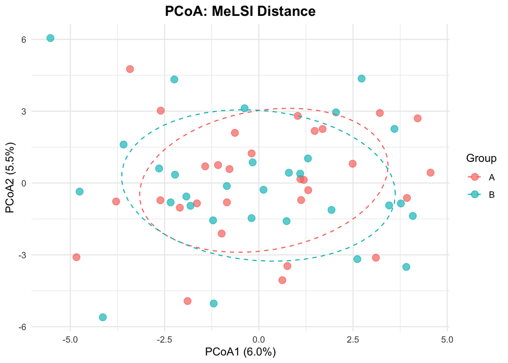

```r
# Create PCoA plot using the learned MeLSI distance matrix
plot_pcoa(melsi_results, X_clr, y, title = "PCoA: MeLSI Distance")
```

## Advanced Usage: Custom Parameters

You can customize MeLSI parameters for your specific needs:

```r
# Run MeLSI with custom parameters
cat("Running MeLSI with custom parameters...\n")
```

```
## Running MeLSI with custom parameters...
```

```r
custom_results <- melsi(
    X_clr, y,
    n_perms = 199,   # More permutations for higher precision (recommended: 200+)
    B = 100,         # Larger ensemble for more stable results
    m_frac = 0.8,    # Fraction of features per learner
    show_progress = TRUE
)
```

[output not shown]

[output cut: 147 more lines]

[output not shown]

```
## Analysis completed!
## F-statistic: 1.3435
## P-value: 0.29
##
## Feature importance: Access results$feature_weights to see which taxa
## contributed most to the learned distance metric.
## Directionality: Access results$directionality to see which group has higher abundance.
##
## Top 5 most important features:
##   1. Taxa60 (weight: 4.6373) [Higher in A]
##   2. Taxa48 (weight: 4.3070) [Higher in A]
##   3. Taxa5 (weight: 4.1591) [Higher in B]
##   4. Taxa17 (weight: 3.8327) [Higher in B]
##   5. Taxa9 (weight: 3.7287) [Higher in B]
```

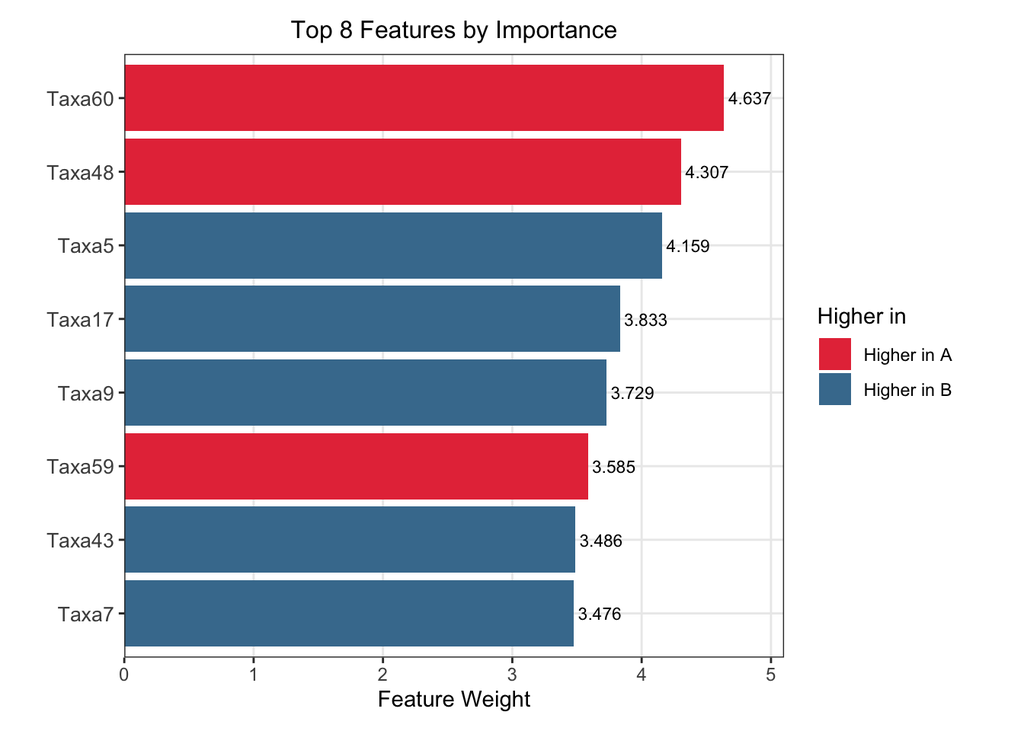

```r
cat(sprintf("Custom MeLSI F-statistic: %.4f (p = %.4f)\n",
           custom_results$F_observed, custom_results$p_value))
```

```
## Custom MeLSI F-statistic: 1.3435 (p = 0.2900)
```

**Parameter Guidelines:** - `n_perms`: Use 200+ for reliable p-values in real analyses - `B`: Default 30 is usually sufficient; increase to 50-100 for more stability - `m_frac`: Default 0.8 works well; lower values (0.6-0.7) can help with very high-dimensional data

## Summary

This tutorial demonstrated:

1. **Basic MeLSI usage** with synthetic microbiome data
2. **Easy data preprocessing** using `clr_transform()`
3. **Automatic visualization** with `plot_vip()` and `plot_pcoa()`
4. **Comparison with standard methods** (Euclidean, Bray-Curtis)
5. **Custom parameters** for advanced usage

### Next Steps

- Try MeLSI on your own microbiome datasets
- Use `clr_transform()` for easy CLR preprocessing
- Visualize results with `plot_vip()` and `plot_pcoa()`
- Adjust parameters (`B`, `m_frac`) if needed for your specific data

For more information, see the main README.md file and the comprehensive documentation.